# Prosper Loan Data Exploration

## Preliminary Wrangling

> This document explores Prosper Loan dataset which contains 113,937 loans with 81 variables on each loan, including loan amount, borrower rate (or interest rate), current loan status, borrower income, and many others. The explanation for each variable can be found [here](https://docs.google.com/spreadsheets/d/1gDyi_L4UvIrLTEC6Wri5nbaMmkGmLQBk-Yx3z0XDEtI/edit#gid=0).

```python
# Import all packages and set plots to be embedded inline
import numpy as np
import pandas as pd
import matplotlib.pyplot as plt
import seaborn as sb

%matplotlib inline
```

```python
# load in the dataset into a pandas dataframe
loan = pd.read_csv('prosperLoanData.csv')

pd.set_option('display.max_columns', None) # Display all the columns
loan.head(10)
```

|  | ListingKey | ListingNumber | ListingCreationDate | CreditGrade | Term | LoanStatus | ClosedDate | BorrowerAPR | BorrowerRate | LenderYield | EstimatedEffectiveYield | EstimatedLoss | EstimatedReturn | ProsperRating (numeric) | ProsperRating (Alpha) | ProsperScore | ListingCategory (numeric) | BorrowerState | Occupation | EmploymentStatus | EmploymentStatusDuration | IsBorrowerHomeowner | CurrentlyInGroup | GroupKey | DateCreditPulled | CreditScoreRangeLower | CreditScoreRangeUpper | FirstRecordedCreditLine | CurrentCreditLines | … |
| --- | --- | --- | --- | --- | --- | --- | --- | --- | --- | --- | --- | --- | --- | --- | --- | --- | --- | --- | --- | --- | --- | --- | --- | --- | --- | --- | --- | --- | --- | --- |
| 0 | 1021339766868145413AB3B | 193129 | 2007-08-26 19:09:29.263000000 | C | 36 | Completed | 2009-08-14 00:00:00 | 0.16516 | 0.1580 | 0.1380 | NaN | NaN | NaN | NaN | NaN | NaN | 0 | CO | Other | Self-employed | 2.0 | True | True | NaN | 2007-08-26 18:41:46.780000000 | 640.0 | 659.0 | 2001-10-11 00:00:00 | 5.0 | … |
| 1 | 10273602499503308B223C1 | 1209647 | 2014-02-27 08:28:07.900000000 | NaN | 36 | Current | NaN | 0.12016 | 0.0920 | 0.0820 | 0.07960 | 0.0249 | 0.05470 | 6.0 | A | 7.0 | 2 | CO | Professional | Employed | 44.0 | False | False | NaN | 2014-02-27 08:28:14 | 680.0 | 699.0 | 1996-03-18 00:00:00 | 14.0 | … |
| 2 | 0EE9337825851032864889A | 81716 | 2007-01-05 15:00:47.090000000 | HR | 36 | Completed | 2009-12-17 00:00:00 | 0.28269 | 0.2750 | 0.2400 | NaN | NaN | NaN | NaN | NaN | NaN | 0 | GA | Other | Not available | NaN | False | True | 783C3371218786870A73D20 | 2007-01-02 14:09:10.060000000 | 480.0 | 499.0 | 2002-07-27 00:00:00 | NaN | … |
| 3 | 0EF5356002482715299901A | 658116 | 2012-10-22 11:02:35.010000000 | NaN | 36 | Current | NaN | 0.12528 | 0.0974 | 0.0874 | 0.08490 | 0.0249 | 0.06000 | 6.0 | A | 9.0 | 16 | GA | Skilled Labor | Employed | 113.0 | True | False | NaN | 2012-10-22 11:02:32 | 800.0 | 819.0 | 1983-02-28 00:00:00 | 5.0 | … |
| 4 | 0F023589499656230C5E3E2 | 909464 | 2013-09-14 18:38:39.097000000 | NaN | 36 | Current | NaN | 0.24614 | 0.2085 | 0.1985 | 0.18316 | 0.0925 | 0.09066 | 3.0 | D | 4.0 | 2 | MN | Executive | Employed | 44.0 | True | False | NaN | 2013-09-14 18:38:44 | 680.0 | 699.0 | 2004-02-20 00:00:00 | 19.0 | … |
| 5 | 0F05359734824199381F61D | 1074836 | 2013-12-14 08:26:37.093000000 | NaN | 60 | Current | NaN | 0.15425 | 0.1314 | 0.1214 | 0.11567 | 0.0449 | 0.07077 | 5.0 | B | 10.0 | 1 | NM | Professional | Employed | 82.0 | True | False | NaN | 2013-12-14 08:26:40 | 740.0 | 759.0 | 1973-03-01 00:00:00 | 21.0 | … |
| 6 | 0F0A3576754255009D63151 | 750899 | 2013-04-12 09:52:56.147000000 | NaN | 36 | Current | NaN | 0.31032 | 0.2712 | 0.2612 | 0.23820 | 0.1275 | 0.11070 | 2.0 | E | 2.0 | 1 | KS | Sales - Retail | Employed | 172.0 | False | False | NaN | 2013-04-12 09:52:53 | 680.0 | 699.0 | 2000-09-29 00:00:00 | 10.0 | … |
| 7 | 0F1035772717087366F9EA7 | 768193 | 2013-05-05 06:49:27.493000000 | NaN | 36 | Current | NaN | 0.23939 | 0.2019 | 0.1919 | 0.17830 | 0.0799 | 0.09840 | 4.0 | C | 4.0 | 2 | CA | Laborer | Employed | 103.0 | False | False | NaN | 2013-05-05 06:49:25 | 700.0 | 719.0 | 1999-02-25 00:00:00 | 6.0 | … |
| 8 | 0F043596202561788EA13D5 | 1023355 | 2013-12-02 10:43:39.117000000 | NaN | 36 | Current | NaN | 0.07620 | 0.0629 | 0.0529 | 0.05221 | 0.0099 | 0.04231 | 7.0 | AA | 9.0 | 7 | IL | Food Service | Employed | 269.0 | True | False | NaN | 2013-12-02 10:43:39 | 820.0 | 839.0 | 1993-04-01 00:00:00 | 17.0 | … |
| 9 | 0F043596202561788EA13D5 | 1023355 | 2013-12-02 10:43:39.117000000 | NaN | 36 | Current | NaN | 0.07620 | 0.0629 | 0.0529 | 0.05221 | 0.0099 | 0.04231 | 7.0 | AA | 11.0 | 7 | IL | Food Service | Employed | 269.0 | True | False | NaN | 2013-12-02 10:43:39 | 820.0 | 839.0 | 1993-04-01 00:00:00 | 17.0 | … |

```python
# Print high-level overview of data shape and composition
print(loan.shape)
print(loan.info())
```

```
(113937, 81)
<class 'pandas.core.frame.DataFrame'>
RangeIndex: 113937 entries, 0 to 113936
Data columns (total 81 columns):
ListingKey                             113937 non-null object
ListingNumber                          113937 non-null int64
ListingCreationDate                    113937 non-null object
CreditGrade                            28953 non-null object
Term                                   113937 non-null int64
LoanStatus                             113937 non-null object
ClosedDate                             55089 non-null object
BorrowerAPR                            113912 non-null float64
BorrowerRate                           113937 non-null float64
LenderYield                            113937 non-null float64
EstimatedEffectiveYield                84853 non-null float64
EstimatedLoss                          84853 non-null float64
EstimatedReturn                        84853 non-null float64
ProsperRating (numeric)                84853 non-null float64
ProsperRating (Alpha)                  84853 non-null object
ProsperScore                           84853 non-null float64
ListingCategory (numeric)              113937 non-null int64
BorrowerState                          108422 non-null object
Occupation                             110349 non-null object
EmploymentStatus                       111682 non-null object
EmploymentStatusDuration               106312 non-null float64
IsBorrowerHomeowner                    113937 non-null bool
CurrentlyInGroup                       113937 non-null bool
GroupKey                               13341 non-null object
DateCreditPulled                       113937 non-null object
CreditScoreRangeLower                  113346 non-null float64
CreditScoreRangeUpper                  113346 non-null float64
FirstRecordedCreditLine                113240 non-null object
CurrentCreditLines                     106333 non-null float64
OpenCreditLines                        106333 non-null float64
TotalCreditLinespast7years             113240 non-null float64
OpenRevolvingAccounts                  113937 non-null int64
OpenRevolvingMonthlyPayment            113937 non-null float64
InquiriesLast6Months                   113240 non-null float64
TotalInquiries                         112778 non-null float64
CurrentDelinquencies                   113240 non-null float64
```

[output cut: 33 more lines]

```
LP_CustomerPrincipalPayments           113937 non-null float64
LP_InterestandFees                     113937 non-null float64
LP_ServiceFees                         113937 non-null float64
LP_CollectionFees                      113937 non-null float64
LP_GrossPrincipalLoss                  113937 non-null float64
LP_NetPrincipalLoss                    113937 non-null float64
LP_NonPrincipalRecoverypayments        113937 non-null float64
PercentFunded                          113937 non-null float64
Recommendations                        113937 non-null int64
InvestmentFromFriendsCount             113937 non-null int64
InvestmentFromFriendsAmount            113937 non-null float64
Investors                              113937 non-null int64
dtypes: bool(3), float64(50), int64(11), object(17)
memory usage: 68.1+ MB
None
```

```python
loan.describe()
```

|  | ListingNumber | Term | BorrowerAPR | BorrowerRate | LenderYield | EstimatedEffectiveYield | EstimatedLoss | EstimatedReturn | ProsperRating (numeric) | ProsperScore | ListingCategory (numeric) | EmploymentStatusDuration | CreditScoreRangeLower | CreditScoreRangeUpper | CurrentCreditLines | OpenCreditLines | TotalCreditLinespast7years | OpenRevolvingAccounts | OpenRevolvingMonthlyPayment | InquiriesLast6Months | TotalInquiries | CurrentDelinquencies | AmountDelinquent | DelinquenciesLast7Years | PublicRecordsLast10Years | PublicRecordsLast12Months | RevolvingCreditBalance | BankcardUtilization | AvailableBankcardCredit | … |
| --- | --- | --- | --- | --- | --- | --- | --- | --- | --- | --- | --- | --- | --- | --- | --- | --- | --- | --- | --- | --- | --- | --- | --- | --- | --- | --- | --- | --- | --- | --- |
| count | 1.139370e+05 | 113937.000000 | 113912.000000 | 113937.000000 | 113937.000000 | 84853.000000 | 84853.000000 | 84853.000000 | 84853.000000 | 84853.000000 | 113937.000000 | 106312.000000 | 113346.000000 | 113346.000000 | 106333.000000 | 106333.000000 | 113240.000000 | 113937.00000 | 113937.000000 | 113240.000000 | 112778.000000 | 113240.000000 | 106315.000000 | 112947.000000 | 113240.000000 | 106333.000000 | 1.063330e+05 | 106333.000000 | 106393.000000 | … |
| mean | 6.278857e+05 | 40.830248 | 0.218828 | 0.192764 | 0.182701 | 0.168661 | 0.080306 | 0.096068 | 4.072243 | 5.950067 | 2.774209 | 96.071582 | 685.567731 | 704.567731 | 10.317192 | 9.260164 | 26.754539 | 6.96979 | 398.292161 | 1.435085 | 5.584405 | 0.592052 | 984.507059 | 4.154984 | 0.312646 | 0.015094 | 1.759871e+04 | 0.561309 | 11210.225447 | … |
| std | 3.280762e+05 | 10.436212 | 0.080364 | 0.074818 | 0.074516 | 0.068467 | 0.046764 | 0.030403 | 1.673227 | 2.376501 | 3.996797 | 94.480605 | 66.458275 | 66.458275 | 5.457866 | 5.022644 | 13.637871 | 4.63097 | 447.159711 | 2.437507 | 6.429946 | 1.978707 | 7158.270157 | 10.160216 | 0.727868 | 0.154092 | 3.293640e+04 | 0.317918 | 19818.361309 | … |
| min | 4.000000e+00 | 12.000000 | 0.006530 | 0.000000 | -0.010000 | -0.182700 | 0.004900 | -0.182700 | 1.000000 | 1.000000 | 0.000000 | 0.000000 | 0.000000 | 19.000000 | 0.000000 | 0.000000 | 2.000000 | 0.00000 | 0.000000 | 0.000000 | 0.000000 | 0.000000 | 0.000000 | 0.000000 | 0.000000 | 0.000000 | 0.000000e+00 | 0.000000 | 0.000000 | … |
| 25% | 4.009190e+05 | 36.000000 | 0.156290 | 0.134000 | 0.124200 | 0.115670 | 0.042400 | 0.074080 | 3.000000 | 4.000000 | 1.000000 | 26.000000 | 660.000000 | 679.000000 | 7.000000 | 6.000000 | 17.000000 | 4.00000 | 114.000000 | 0.000000 | 2.000000 | 0.000000 | 0.000000 | 0.000000 | 0.000000 | 0.000000 | 3.121000e+03 | 0.310000 | 880.000000 | … |
| 50% | 6.005540e+05 | 36.000000 | 0.209760 | 0.184000 | 0.173000 | 0.161500 | 0.072400 | 0.091700 | 4.000000 | 6.000000 | 1.000000 | 67.000000 | 680.000000 | 699.000000 | 10.000000 | 9.000000 | 25.000000 | 6.00000 | 271.000000 | 1.000000 | 4.000000 | 0.000000 | 0.000000 | 0.000000 | 0.000000 | 0.000000 | 8.549000e+03 | 0.600000 | 4100.000000 | … |
| 75% | 8.926340e+05 | 36.000000 | 0.283810 | 0.250000 | 0.240000 | 0.224300 | 0.112000 | 0.116600 | 5.000000 | 8.000000 | 3.000000 | 137.000000 | 720.000000 | 739.000000 | 13.000000 | 12.000000 | 35.000000 | 9.00000 | 525.000000 | 2.000000 | 7.000000 | 0.000000 | 0.000000 | 3.000000 | 0.000000 | 0.000000 | 1.952100e+04 | 0.840000 | 13180.000000 | … |
| max | 1.255725e+06 | 60.000000 | 0.512290 | 0.497500 | 0.492500 | 0.319900 | 0.366000 | 0.283700 | 7.000000 | 11.000000 | 20.000000 | 755.000000 | 880.000000 | 899.000000 | 59.000000 | 54.000000 | 136.000000 | 51.00000 | 14985.000000 | 105.000000 | 379.000000 | 83.000000 | 463881.000000 | 99.000000 | 38.000000 | 20.000000 | 1.435667e+06 | 5.950000 | 646285.000000 | … |

### Cleaning

```python
# Define columns of interest used for predicting loan status
cols_to_keep = ['Term', 'ProsperScore', 'BorrowerAPR', 'EmploymentStatus', 'EmploymentStatusDuration', 'DebtToIncomeRatio',
               'StatedMonthlyIncome', 'IncomeVerifiable', 'MonthlyLoanPayment', 'LoanOriginalAmount', 'LoanStatus']

loan = loan[cols_to_keep]
```

> Get unique values for 'EmploymentStatus' column and replace 'Not available' with NaN

```python
# Get unique values for 'EmploymentStatus' column
loan.EmploymentStatus.unique()
```

```
array(['Self-employed', 'Employed', 'Not available', 'Full-time', 'Other',
       nan, 'Not employed', 'Part-time', 'Retired'], dtype=object)
```

```python
# Replace 'Not available' in 'EmploymentStatus' column with NaN
loan.EmploymentStatus.replace('Not available', np.nan, inplace=True)

# Test
loan.EmploymentStatus.unique()
```

```
array(['Self-employed', 'Employed', nan, 'Full-time', 'Other',
       'Not employed', 'Part-time', 'Retired'], dtype=object)
```

> Get unique values for 'IncomeVerifiable' column

```python
# Get unique values for 'IncomeVerifiable' column
loan.IncomeVerifiable.unique()
```

```
array([ True, False], dtype=bool)
```

> Get unique values for 'LoanStatus' column and categorize all different types of 'PastDue' (Past Due (16-30 days), Past Due (31-60 days) and etc) into 'PastDue'

```python
# Get unique values for 'LoanStatus' column
loan.LoanStatus.unique()
```

```
array(['Completed', 'Current', 'Past Due (1-15 days)', 'Defaulted',
       'Chargedoff', 'Past Due (16-30 days)', 'Cancelled',
       'Past Due (61-90 days)', 'Past Due (31-60 days)',
       'Past Due (91-120 days)', 'FinalPaymentInProgress',
       'Past Due (>120 days)'], dtype=object)
```

```python
# Categorize all different types of 'PastDue' (Past Due (16-30 days), Past Due (31-60 days) and etc) into 'PastDue'
loan.LoanStatus = loan.LoanStatus.apply(lambda x: 'Past Due' if 'Past Due' in x else x)

# Test
loan.LoanStatus.unique()
```

```
array(['Completed', 'Current', 'Past Due', 'Defaulted', 'Chargedoff',
       'Cancelled', 'FinalPaymentInProgress'], dtype=object)
```

> Remove rows with NaN value in any of the column

```python
# Print number of rows of the original data frame and number of rows with NaN value in any of the column
print("Number of rows in the original data frame: {}".format(len(loan)))
print("Number of rows with NaN value: {}".format(sum(loan.isnull().any(axis=1))))
```

```
Number of rows in the original data frame: 113937
Number of rows with NaN value: 36394
```

```python
# Remove rows with NaN value in any of the column for the ease of plotting
loan = loan[~loan.isnull().any(axis=1)]
```

### What is the structure of your dataset?

- Term
- BorrowerAPR
- ProsperScore
- EmploymentStatus
- EmploymentStatusDuration
- DebtToIncomeRatio
- StatedMonthlyIncome
- IncomeVerifiable
- MonthlyLoanPayment
- LoanOriginalAmount
- LoanStatus

### What is/are the main feature(s) of interest in your dataset?

I'm most interested in figuring out what features are useful in predicting the loan's outcome status in the dataset.

### What features in the dataset do you think will help support your investigation into your feature(s) of interest?

I expect that the 10 features listed above will have effect on the loan's outcome status. However, it is difficult to estimate which features will have stronger effect on the loan's outcome status at this point. Thus, analysis and visualization will be carried out to determine how these features affect the loan's outcome status.

## Univariate Exploration

I'll start by looking at the distribution of the main variable of interest: `LoanStatus`.

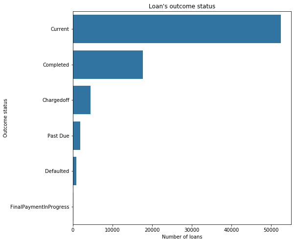

```python
# Plot bar chart of 'LoanStatus'
default_color = sb.color_palette()[0]

# Get each unique value in 'LoanStatus' based on the frequency in descending order
cat_order = loan['LoanStatus'].value_counts().index

plt.figure(figsize=[8, 8])
sb.countplot(data = loan, y = 'LoanStatus', color=default_color, order=cat_order)
plt.title('Loan\'s outcome status')
plt.xlabel('Number of loans')
plt.ylabel('Outcome status');
```

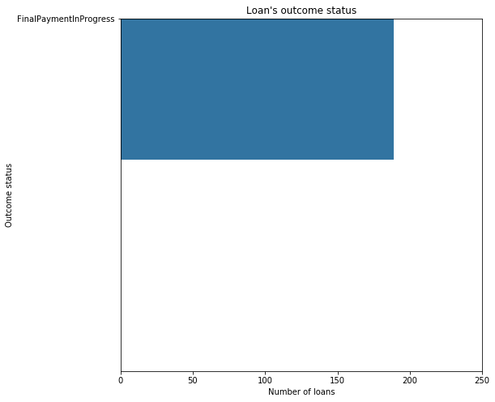

```python
# Get a zoom-in view on 'FinalPaymentinProgress' and 'Cancelled' status
default_color = sb.color_palette()[0]

# Get each unique value in 'LoanStatus' based on the frequency in descending order
cat_order = loan['LoanStatus'].value_counts().index

plt.figure(figsize=[8, 8])
sb.countplot(data = loan, y = 'LoanStatus', color=default_color, order=cat_order)
plt.title('Loan\'s outcome status')
plt.xlabel('Number of loans')
plt.ylabel('Outcome status')
plt.xlim(0,250)
plt.ylim(6,5);
```

Next up, the first predictor variable of interest: Term.

```python
# Get unique values for 'Term' column
loan.Term.unique()
```

```
array([36, 60, 12])
```

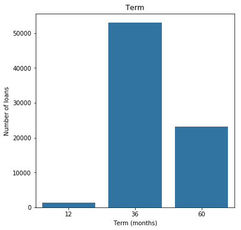

```python
# Plot bar chart of 'LoanStatus'
default_color = sb.color_palette()[0]

# Sort 'Term' from smallest to larger
order = np.sort(loan.Term.unique())

plt.figure(figsize=[6, 6])
sb.countplot(data = loan, x = 'Term', color=default_color, order=order)
plt.title('Term')
plt.xlabel('Term (months)')
plt.ylabel('Number of loans');
```

> The most frequent term is 36 months, followed by 60 months. The least frequent term is 12 months

Next up, the second predictor variable of interest: BorrowerAPR.

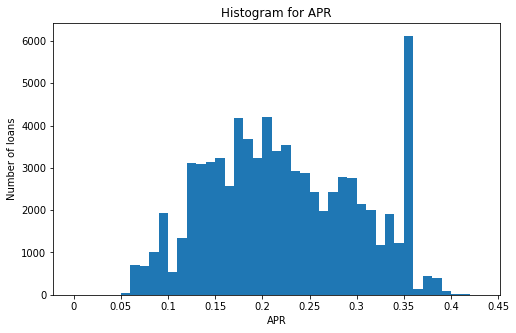

```python
# Plot standard-scaled histogram for BorrowerAPR
binsize = 0.01
bins = np.arange(0, loan.BorrowerAPR.max()+binsize, binsize)

plt.figure(figsize=[8, 5])
plt.hist(data = loan, x = 'BorrowerAPR', bins = bins)
plt.title('Histogram for APR')
plt.xlabel('APR')
plt.ylabel('Number of loans')
xticks = [0, 0.05, 0.1, 0.15, 0.2, 0.25, 0.3, 0.35, 0.4, 0.45]
plt.xticks(xticks, xticks);
```

Next up, the third predictor variable of interest: DebtToIncomeRatio.

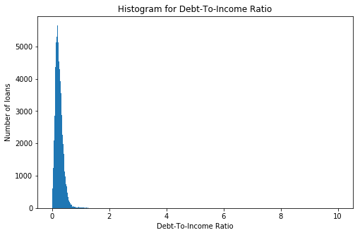

```python
# Plot standard-scaled histogram for DebtToIncomeRatio
binsize = 0.02
bins = np.arange(0, loan.DebtToIncomeRatio.max()+binsize, binsize)

plt.figure(figsize=[8, 5])
plt.hist(data = loan, x = 'DebtToIncomeRatio', bins = bins)
plt.title('Histogram for Debt-To-Income Ratio')
plt.xlabel('Debt-To-Income Ratio')
plt.ylabel('Number of loans');
```

From the histogram, it can be seen that almost all the borrowers have low debt-to-income ratio and a minority of the borrowers have high debt-to-income ratio. It is crucial to get a zoom-in view on both low (<1) and high (>1) debt-to-income ratio regions to gain more insights. Low debt-to-income ratio is defined as debt-to-income ratio that is smaller than 1, which means the borrower's debt is smaller than his or her income.

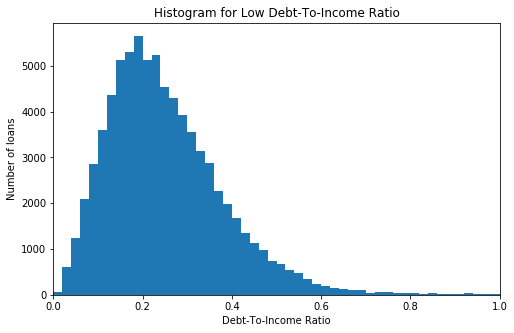

```python
# Get a zoom-in view on low debt-to-income ratio region
binsize = 0.02
bins = np.arange(0, loan.DebtToIncomeRatio.max()+binsize, binsize)

plt.figure(figsize=[8, 5])
plt.hist(data = loan, x = 'DebtToIncomeRatio', bins = bins)
plt.title('Histogram for Low Debt-To-Income Ratio')
plt.xlabel('Debt-To-Income Ratio')
plt.ylabel('Number of loans')
plt.xlim(0,1);
```

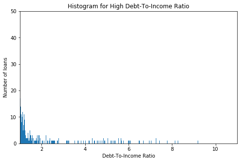

```python
# Get a zoom-in view on high debt-to-income ratio region
binsize = 0.02
bins = np.arange(0, loan.DebtToIncomeRatio.max()+binsize, binsize)

plt.figure(figsize=[8, 5])
plt.hist(data = loan, x = 'DebtToIncomeRatio', bins = bins)
plt.title('Histogram for High Debt-To-Income Ratio')
plt.xlabel('Debt-To-Income Ratio')
plt.ylabel('Number of loans')
plt.xlim(1,11)
plt.ylim(0,50);
```

Next up, the fourth predictor variable of interest: StatedMonthlyIncome.

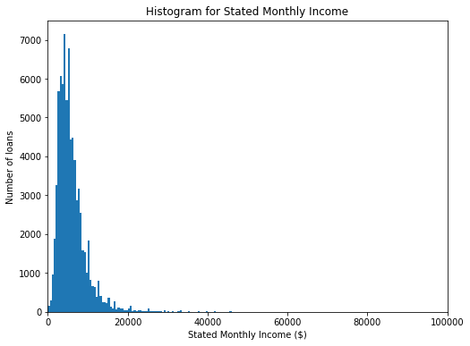

```python
# Plot standard-scaled histogram for StatedMonthlyIncome
binsize = 500
bins = np.arange(0, loan.StatedMonthlyIncome.max()+binsize, binsize)

plt.figure(figsize=[8, 6])
plt.hist(data = loan, x = 'StatedMonthlyIncome', bins = bins)
plt.title('Histogram for Stated Monthly Income')
plt.xlabel('Stated Monthly Income ($)')
plt.ylabel('Number of loans')
plt.xlim(0, 100000);
```

```python
# Retrieve rows that correspond to extremely high stated monthly income (>30000)
loan_high_stated_monthly_income = loan[loan.StatedMonthlyIncome > 30000]

# Print number and percentage of rows that correspond to extremely high stated monthly income (>30000)
print("Number of rows: {}".format(len(loan_high_stated_monthly_income)))
print("Percentage: {}".format(len(loan_high_stated_monthly_income)/len(loan)))
```

```
Number of rows: 191
Percentage: 0.0024631494783539454
```

```python
# Remove rows that correspond to extremely high stated monthly income (>30000)
loan = loan[loan.StatedMonthlyIncome <= 30000]
```

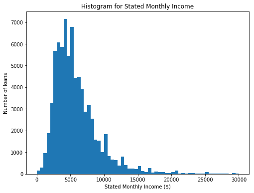

```python
# Plot standard-scaled histogram for StatedMonthlyIncome after outliers are removed
binsize = 500
bins = np.arange(0, loan.StatedMonthlyIncome.max()+binsize, binsize)

plt.figure(figsize=[8, 6])
plt.hist(data = loan, x = 'StatedMonthlyIncome', bins = bins)
plt.title('Histogram for Stated Monthly Income')
plt.xlabel('Stated Monthly Income ($)')
plt.ylabel('Number of loans');
```

The distribution of stated monthly income is skewed right, with majority of the borrowers having stated monthly income between 2500 and 10000.

Next up, the fifth predictor variable of interest: MonthlyLoanPayment.

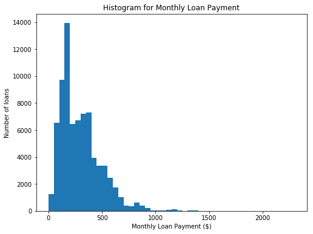

```python
# Plot standard-scaled histogram for MonthlyLoanPayment after outliers are removed
binsize = 50
bins = np.arange(0, loan.MonthlyLoanPayment.max()+binsize, binsize)

plt.figure(figsize=[8, 6])
plt.hist(data = loan, x = 'MonthlyLoanPayment', bins = bins)
plt.title('Histogram for Monthly Loan Payment')
plt.xlabel('Monthly Loan Payment ($)')
plt.ylabel('Number of loans');
```

The distribution of monthly loan payment is skewed right, with a very sharp peak roughly located at slightly below 250

Next up, the sixth predictor variable of interest: LoanOriginalAmount

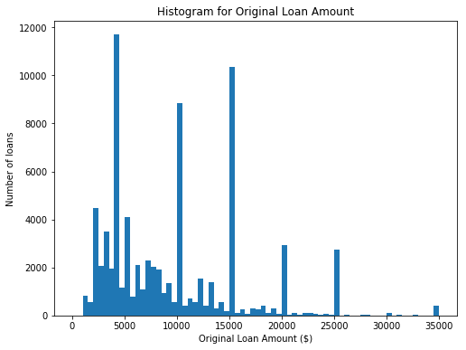

```python
# Plot standard-scaled histogram for LoanOriginalAmount
binsize = 500
bins = np.arange(0, loan.LoanOriginalAmount.max()+binsize, binsize)

plt.figure(figsize=[8, 6])
plt.hist(data = loan, x = 'LoanOriginalAmount', bins = bins)
plt.title('Histogram for Original Loan Amount')
plt.xlabel('Original Loan Amount ($)')
plt.ylabel('Number of loans');
```

There are very large spikes in frequency at certain original loan amount (roughly at 4000, 10000, 15000, 20000, 25000). These probably represent standard original loan amount offered by Prosper.

Next up, the seventh predictor variable of interest: ProsperScore

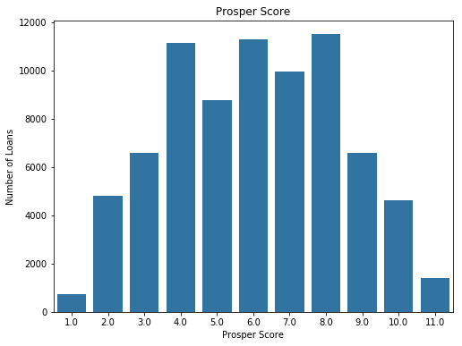

```python
# Plot bar chart for ProsperScore
default_color = sb.color_palette()[0]

plt.figure(figsize=[8, 6])
sb.countplot(data = loan, x = 'ProsperScore', color = default_color)
plt.title('Prosper Score')
plt.xlabel('Prosper Score')
plt.ylabel('Number of Loans');
```

Most of risk scores fall within 4 and 8 points.

Next up, the eighth and ninth predictor variable of interest: EmploymentStatus & EmploymentStatusDuration

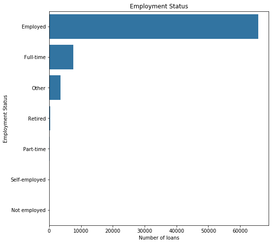

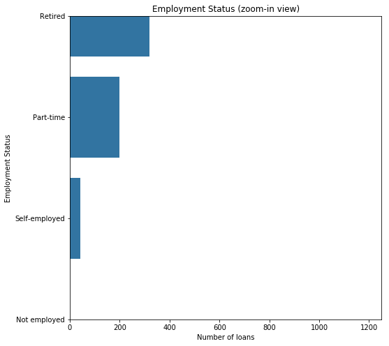

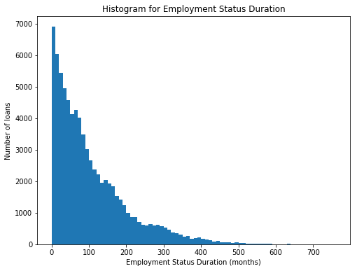

```python
# Plot bar chart of EmploymentStatus
default_color = sb.color_palette()[0]

# Get each unique value in 'EmployementStatus' based on the frequency in descending order
cat_order = loan['EmploymentStatus'].value_counts().index

plt.figure(figsize=[8, 8])
sb.countplot(data = loan, y = 'EmploymentStatus', color=default_color, order=cat_order)
plt.title('Employment Status')
plt.xlabel('Number of loans')
plt.ylabel('Employment Status');

# Get a zoom-in view on 'Self-employed', 'Part-time', 'Retired' and 'Not employed' status
plt.figure(figsize=[8, 8])
sb.countplot(data = loan, y = 'EmploymentStatus', color=default_color, order=cat_order)
plt.title('Employment Status (zoom-in view)')
plt.xlabel('Number of loans')
plt.ylabel('Employment Status');
plt.xlim(0,1250)
plt.ylim(6,3);

# Plot standard-scaled histogram for EmploymentStatusDuration
binsize = 10
bins = np.arange(0, loan.EmploymentStatusDuration.max()+binsize, binsize)

plt.figure(figsize=[8, 6])
plt.hist(data = loan, x = 'EmploymentStatusDuration', bins = bins)
plt.title('Histogram for Employment Status Duration')
plt.xlabel('Employment Status Duration (months)')
plt.ylabel('Number of loans');
```

Majority of the borrowers are employed. The distribution of employment status duration is very right skewed.

Next up, the tenth predictor variable of interest: IncomeVerifiable

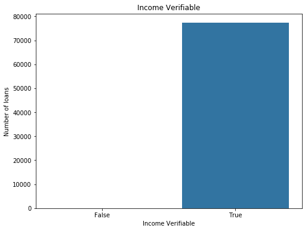

```python
# Plot bar chart of EmploymentStatus
default_color = sb.color_palette()[0]
plt.figure(figsize=[8, 6])
sb.countplot(data = loan, x = 'IncomeVerifiable', color = default_color)
plt.title('Income Verifiable')
plt.xlabel('Income Verifiable')
plt.ylabel('Number of loans');
```

```python
# Print number of income that is not verifiable
print("{} out of {} are not verifiable".format(sum(~loan.IncomeVerifiable), len(loan)))
```

```
47 out of 77352 are not verifiable
```

Majority of the borrowers have their incomes verifiable.

## Bivariate Exploration

To start off with, pairwise correlations present between features in the data are studied.

```python
# Numerical variable
numeric_vars = ['BorrowerAPR', 'EmploymentStatusDuration', 'DebtToIncomeRatio', 'StatedMonthlyIncome',
                'MonthlyLoanPayment', 'LoanOriginalAmount']

# Categorical variable (IncomeVerifiable is not included as it is not predictive loan's outcome status)
categoric_vars = ['LoanStatus', 'Term', 'ProsperScore', 'EmploymentStatus']
```

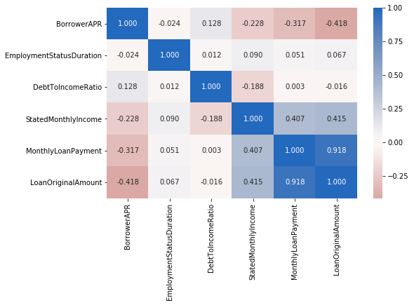

```python
# Correlation plot
plt.figure(figsize = [8, 5])
sb.heatmap(loan[numeric_vars].corr(), annot = True, fmt = '.3f',
           cmap = 'vlag_r', center = 0)
plt.show()
```

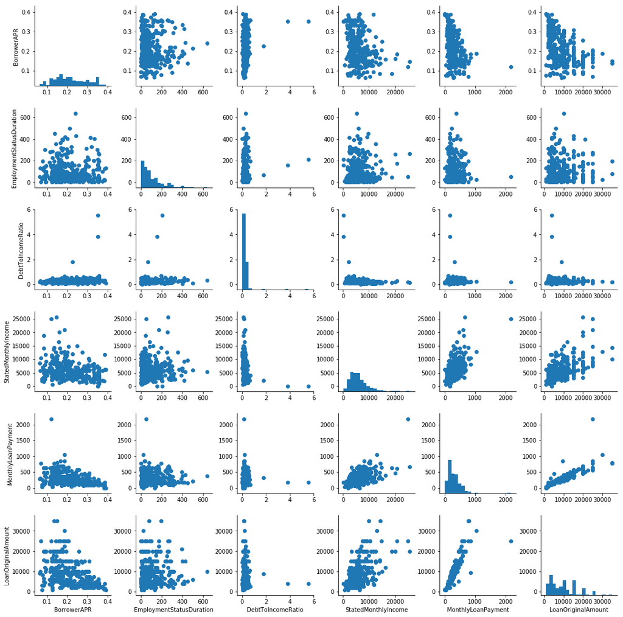

```python
# Plot matrix: sample 500 loans so that plots are clearer and they render faster
samples = np.random.choice(loan.shape[0], 500, replace = False)
loan_samp = loan.loc[samples]

g = sb.PairGrid(data = loan_samp.dropna(), vars = numeric_vars)
g = g.map_diag(plt.hist, bins = 20)
g.map_offdiag(plt.scatter);
```

As expected, LoanOriginalAmount and MonthlyLoanPayment are highly correlated with one another. This means that if a borrower borrows more loan, then he or she has repay loan more each month. Furthermore, there is a slight correlation between StatedMonthlyIncome and MonthlyLoanPayment. This may suggest that StatedMonthlyIncome could be one of the factors when it comes to determining MonthlyLoanPayment. Another observation is there is a slight correlation between LoanOriginalAmount and StatedMonthlyIncome. This may suggest that Prosper is using StatedMonthlyIncome as one of the criteria to decide LoanOriginalAmount.

Let's move on to looking at how LoanOriginalAmount, MonthlyLoanPayment and StatedMonthlyIncome correlate with LoanStatus

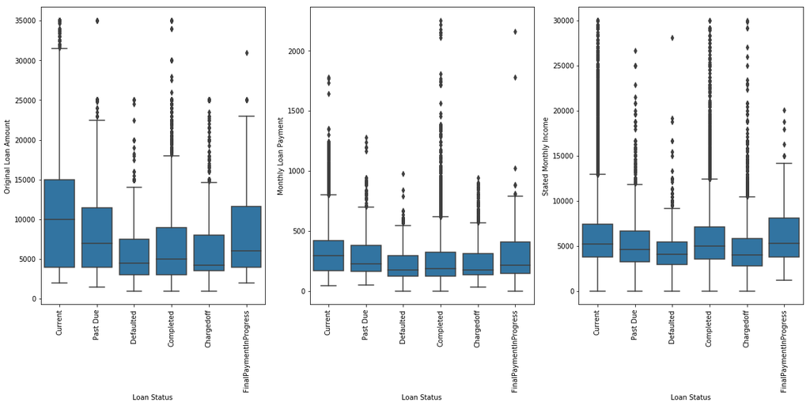

```python
default_color = sb.color_palette()[0]

# Plot boxplot to study the correlation between LoanOriginalAmount and LoanStatus
plt.figure(figsize = [20, 8])
plt.subplot(1, 3, 1)
ax1 = sb.boxplot(data=loan, x='LoanStatus', y='LoanOriginalAmount', color = default_color)
plt.xlabel('Loan Status')
plt.ylabel('Original Loan Amount')
plt.xticks(rotation=90);

# Plot boxplot to study the correlation between MonthlyLoanPayment and LoanStatus
plt.subplot(1, 3, 2)
ax2 = sb.boxplot(data=loan, x='LoanStatus', y='MonthlyLoanPayment', color = default_color)
plt.xlabel('Loan Status')
plt.ylabel('Monthly Loan Payment')
plt.xticks(rotation=90);

# Plot boxplot to study the correlation between StatedMonthlyIncome and LoanStatus
plt.subplot(1, 3, 3)
ax3 = sb.boxplot(data=loan, x='LoanStatus', y='StatedMonthlyIncome', color = default_color)
plt.xlabel('Loan Status')
plt.ylabel('Stated Monthly Income')
plt.xticks(rotation=90);
```

Interestingly, it appears that there are some relationships between the three numeric variables of interest and loan status. Loans that defaulted or charged-off seem to have lower original loan amount, monthly loan payment and stated monthly income than other loan's outcome status. Loans that are currently ongoing have higher original loan amount, monthly loan payment and stated monthly income than other loan's outcome status. As original loan amount, monthly loan payment and stated monthly income have some correlation with one another, it is not suprising to find out that loan's outcome status have similar relationship with these features

Next up, let's look at how BorrowerAPR, EmploymentStatusDuration, DebtToIncomeRatio correlate with LoanStatus.

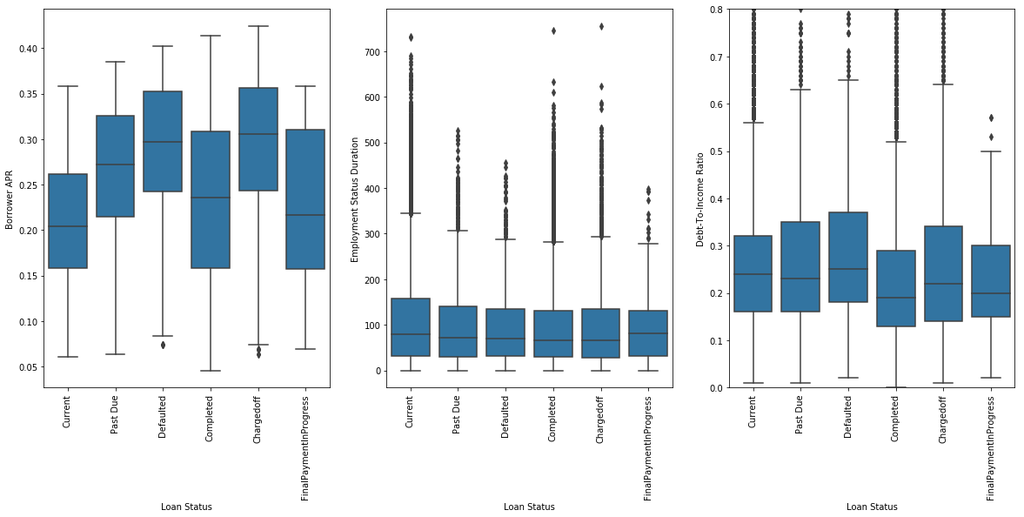

```python
default_color = sb.color_palette()[0]

# Plot boxplot to study the correlation between BorrowerAPR and LoanStatus
plt.figure(figsize = [20, 8])
plt.subplot(1, 3, 1)
ax1 = sb.boxplot(data=loan, x='LoanStatus', y='BorrowerAPR', color = default_color)
plt.xlabel('Loan Status')
plt.ylabel('Borrower APR')
plt.xticks(rotation=90);

# Plot boxplot to study the correlation between EmploymentStatusDuration and LoanStatus
plt.subplot(1, 3, 2)
ax2 = sb.boxplot(data=loan, x='LoanStatus', y='EmploymentStatusDuration', color = default_color)
plt.xlabel('Loan Status')
plt.ylabel('Employment Status Duration')
plt.xticks(rotation=90);

# Plot boxplot to study the correlation between DebtToIncomeRatio and LoanStatus
plt.subplot(1, 3, 3)
ax3 = sb.boxplot(data=loan, x='LoanStatus', y='DebtToIncomeRatio', color = default_color)
plt.xlabel('Loan Status')
plt.ylabel('Debt-To-Income Ratio')
plt.xticks(rotation=90)
plt.ylim(0,0.8);
```

Based on the box plot (leftmost) for BorrowerAPR and LoanStatus, loans that defaulted or charged-off have higher BorrowerAPR than other loan's outcome status. Whereas loans that are currently ongoing or in final payment process have lower BorrowerAPR.

Based on the box plot (middle) for EmploymentStatusDuration and LoanStatus, all the loan's status outcome have similar employment status duration. This suggests that there is no relationship between employment status duration and loan status.

Based on the box plot (rightmost) for DebtToIncomeRatio and LoanStatus, the loans with highest debt-to-income ratio are defaulted loan, followed by past due loans and charged-off loans. This could be a worrying sign for Prosper because current loans have high debt-to-income ratio, just like defaulted loan and past due loans

Next up, let's study the relationship between each categorical variable and LoanStatus.

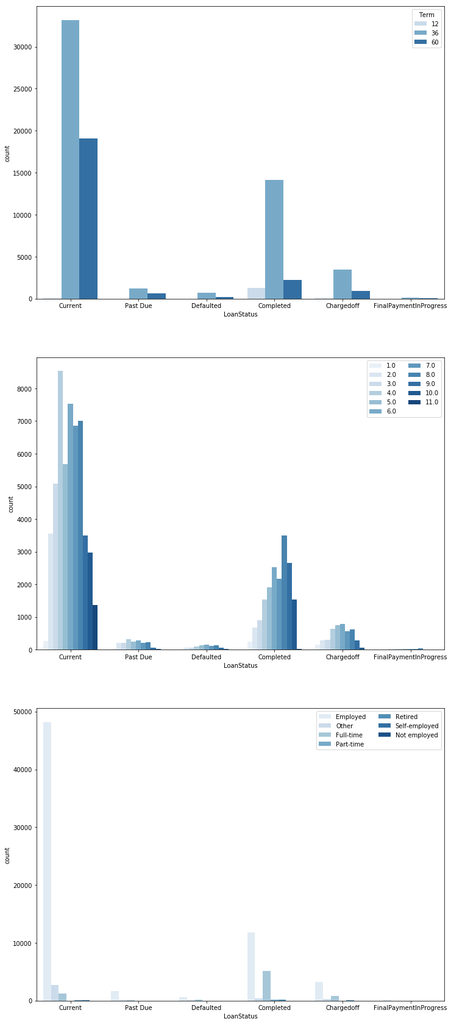

```python
plt.figure(figsize = [12, 30])

# Subplot 1: LoanStatus vs Term
plt.subplot(3, 1, 1)
sb.countplot(data = loan, x = 'LoanStatus', hue = 'Term', palette = 'Blues')

# Subplot 2: LoanStatus vs ProsperScore
ax = plt.subplot(3, 1, 2)
sb.countplot(data = loan, x = 'LoanStatus', hue = 'ProsperScore', palette = 'Blues')
ax.legend(ncol = 2) # re-arrange legend to reduce overlapping

# Subplot 3: LoanStatus vs EmploymentStatus
ax = plt.subplot(3, 1, 3)
sb.countplot(data = loan, x = 'LoanStatus', hue = 'EmploymentStatus', palette = 'Blues')
ax.legend(loc = 1, ncol = 2) # re-arrange legend to remove overlapping

plt.show()
```

There doesn't seem to be that much interaction between loan's status outcome and term, though proportionally it seems like more current, completed and charged-off loans are 36-month loans. Similarly, there doesn't seem to be that much interaction between loan's status outcome and ProsperScore.

Based on the third subplot, most of the borrowers are employed or working full-time regardless of the loan's status outcome, except for FinalPaymentInProgress loans as there is insufficient data to show.

### Talk about some of the relationships you observed in this part of the investigation. How did the feature(s) of interest vary with other features in the dataset?

LoanOriginalAmount and MonthlyLoanPayment are highly correlated with one another. Besides that, there is a slight correlation between StatedMonthlyIncome and MonthlyLoanPayment and between LoanOriginalAmount and StatedMonthlyIncome.

There was also an interesting relationship observed between loan status and three numeric variables of interest (LoanOriginalAmount, MonthlyLoanPayment and StatedMonthlyIncome). Defaulted and charged-off loans have lower original loan amount, monthly loan payment and stated monthly income than other loan's outcome status. Current loans have higher original loan amount, monthly loan payment and stated monthly income than other loan's outcome status. As original loan amount, monthly loan payment and stated monthly income have some correlation with one another, it is not suprising to find out that loan's outcome status have similar relationship with these features.

Defaulted and charged-off loans have higher BorrowerAPR than other loan's outcome status. Whereas loans that are currently ongoing or in final payment process have lower BorrowerAPR. Loans with highest debt-to-income ratio are defaulted loan, followed by past due loans and charged-off loans.

### Did you observe any interesting relationships between the other features (not the main feature(s) of interest)?

All the loan's status outcome have similar employment status duration. Besides that, there doesn't seem to be that much interaction between loan's status outcome and term and between loan's status outcome and ProsperScore. Among all the borrowers, majority of them are employed or working full-time regardless of the loan's status outcome, except for FinalPaymentInProgress loans as there is insufficient data to show.

## Multivariate Exploration

The main thing I want to explore in this part of the analysis is how LoanOriginalAmount and BorrowerAPR affect LoanStatus

```python
def hist2dgrid(x, y, **kwargs):
    """ Quick hack for creating heat maps with seaborn's PairGrid. """
    palette = kwargs.pop('color')
    bins_x = np.arange(0, 0.42+0.01, 0.01)
    bins_y = np.arange(0, 35000+500, 500)
    plt.hist2d(x, y, bins = [bins_x, bins_y], cmap = palette, cmin = 0.5)
    plt.hist2d(x, y, cmap = palette, cmin = 0.5)
```

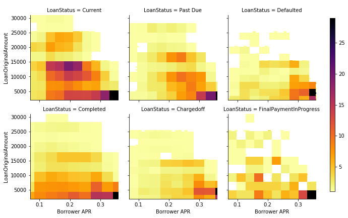

```python
# Create faceted heat maps on levels of LoanStatus
fig = plt.figure()

g = sb.FacetGrid(data = loan, col = 'LoanStatus', col_wrap = 3, size = 3)
g.map(hist2dgrid, 'BorrowerAPR', 'LoanOriginalAmount', color = 'inferno_r')
g.set_xlabels('Borrower APR')
cbar_ax = g.fig.add_axes([1.015,0.13, 0.015, 0.8])
plt.colorbar(cax=cbar_ax)
plt.show()
```

By analyzing the heatmaps above, it can be seen that defaulted, charged-off, past due and FinalPaymentInProgress loans are mostly loans with low original loan amount (<10000) but high annual percentage rate (APR). It can be observed aforementioned loans are concentrated at the bottom right corner of the heatmap

For completed loans, the loans are mostly loans with low original loan amount (<10000) and APR of any values (could be low or high). In the heatmap, it can be observed that completed loans are concentrated at the bottom of the heatmap, indicating that they are loans with low amount and their APRs can have a wide range of values

For current loans, most of the loans have loan amount less than 15000 and APR of any values. It can be observed that current loans are concentrated in the center and bottom right of the heatmap. It is interesting to see that there is high concentration of current loans in the center of the heatmap, which is not really seen in other loan's outcome status. This may suggest that Prosper is increasing the loan amount recently.

From the data displayed via heatmap, it seems like loans with small loan amount and small APR are likely to be repaid by the borrowers. For loans with small loan amount and high APR, it is difficult to deduce the loan's outcome status solely based on LoanOriginalAmount and BorrowerAPR.

### Talk about some of the relationships you observed in this part of the investigation. Were there features that strengthened each other in terms of looking at your feature(s) of interest?

> Defaulted, charged-off, past due and FinalPaymentInProgress loans are mostly loans with low original loan amount (<10000) but high annual percentage rate (APR). Completed loans are mostly loans with low original loan amount (<10000) and APR of any values (could be low or high). Current loans have loan amount less than 15000 and APR of any values.

### Were there any interesting or surprising interactions between features?

> It is interesting to see that a lot of current loans have loan amount between 12500 and 15000, which is not really seen in other loan's outcome status. This may suggest that Prosper is increasing the loan amount recently. From the data displayed via heatmap, it seems like loans with small loan amount and small APR are likely to be repaid by the borrowers. For loans with small loan amount and high APR, it is difficult to deduce the loan's outcome status solely based on LoanOriginalAmount and BorrowerAPR.